# 2 - Importació i Manipulació bàsica

Eudald Correig

10/6/2019

# Importar bases de dades

- R sap llegir dades de gairebé qualsevol format.
- El sistema és habitualment senzill i només cal tenir en compte quina llibreria cal en cada cas.
- En general, l’objecte generat és un dataframe

Resum de comandes per als formats més utilitzats:

| Format | Llibreria | Sintaxis |
| --- | --- | --- |
| Text (.csv) | Base/Readr | read.csv(ruta, header=TRUE, row.names=‘id’) |
| Text (.txt/ .csv) | Base/Readr/data.table | read.table(ruta, header=TRUE, sep=‘,’, row.names=‘id’) |
| MSExcel (.xls / .xlsx) | openxlsx | read.xlsx( ruta, sheet) |
| SPSS (.sav) | foreign | read.spss(ruta) |
| Stata (.dta) | foreign | read.dta( ruta) |
| SAS (.xpt) | foreign | Read.xport(ruta) |

## Importar fitxers de text (.txt, .csv)

```r
df = read.table("ruta",
                header=TRUE,   #primera línia noms variables
                sep="," ,  #separador entre variables
                stringsAsFactors = FALSE,   #no factors per defecte
                na.strings=c("NA","**"), #codis per a missings
                dec="." #simbol decimal
)
```

## Importar fitxers MS Excel

```r
library(openxlsx)

df = read.xlsx("ruta",
               sheetIndex,  #nº de fulla (evitar posar el nom)
               sheetName="Full1", #nom de la fulla
               as.data.frame=TRUE, #com un data frame
               header=TRUE,  #noms variables
               rowIndex=20, #número de files per llegir
)
```

## Importar fitxers SPSS

```r
library(foreign)

df = read.spss("ruta",
               use.value.labels=TRUE,  # factors
               to.data.frame=TRUE, #data frame
)
```

## Exemple

```r
dades = read.csv("datasets/dades.csv", row.names="id")
```

# Exploració de les dades

## Veure les dades (tipus excel)

```r
View(dades) # mostra tot el conjunt de dades
```

**Nota**: aquesta comanda, com ja hem vist, no és recomanable que la posem en un markdown, simplement l’escrivim a la consola, ja que si no pot provocar problemes a l’hora de fer “Knit”.

## Estructura

Fem una ullada a les dades

```r
str(dades) #mostra estructura d'un objecte
```

```
## 'data.frame':    10 obs. of  4 variables:
##  $ sexe   : Factor w/ 2 levels "D","M": 2 1 2 1 2 1 2 1 2 1
##  $ normal : num  0.501 -0.309 -0.657 -0.779 -1.681 ...
##  $ curacio: logi  FALSE TRUE FALSE TRUE FALSE TRUE ...
##  $ edat   : int  67 78 89 86 56 90 68 82 92 67
```

## Primeres o últimes files

```r
head(dades) #mostra les primeres files
```

```
##   sexe     normal curacio edat
## 1    M  0.5010061   FALSE   67
## 2    D -0.3094905    TRUE   78
## 3    M -0.6568773   FALSE   89
## 4    D -0.7792013    TRUE   86
## 5    M -1.6813112   FALSE   56
## 6    D  0.6612151    TRUE   90
```

```r
tail(dades) #mostra les darreres files
```

[output not shown]

## Resums

Fem un resum de totes les variables amb:

```r
summary(dades)
```

```
##  sexe      normal         curacio             edat
##  D:5   Min.   :-1.6813   Mode :logical   Min.   :56.00
##  M:5   1st Qu.:-0.5700   FALSE:5         1st Qu.:67.25
##        Median : 0.5091   TRUE :5         Median :80.00
##        Mean   : 0.1194                   Mean   :77.50
##        3rd Qu.: 0.6295                   3rd Qu.:88.25
##        Max.   : 1.4260                   Max.   :92.00
```

Visualització ràpida

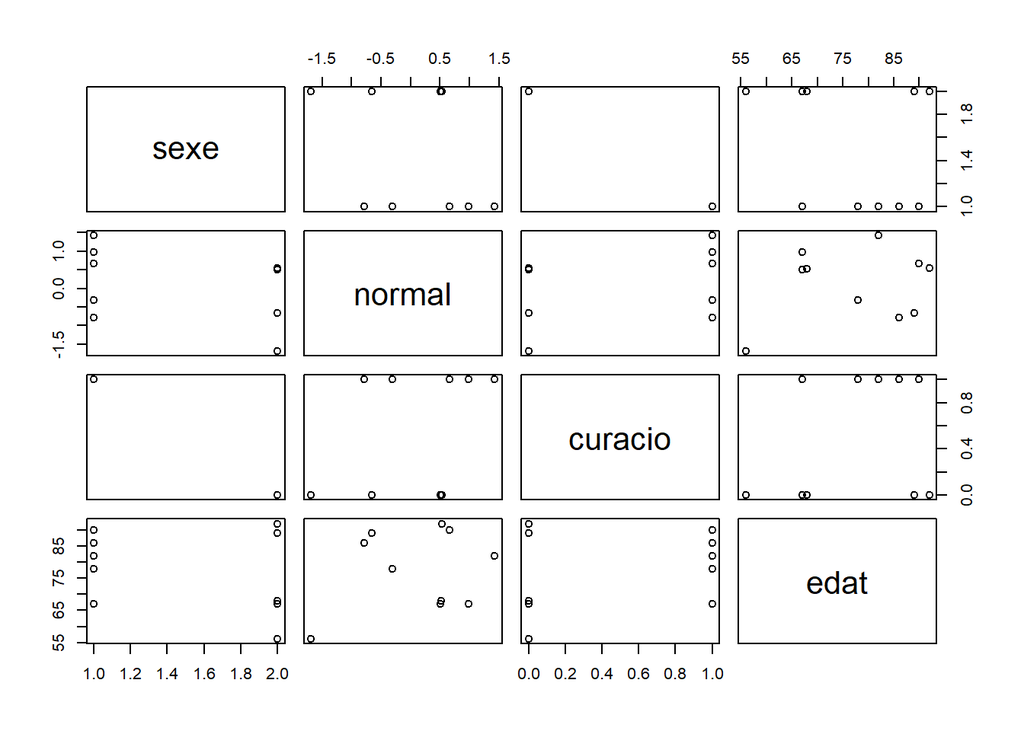

```r
pairs(dades)
```

# Manipulació de variables

## Creació noves variables

Entrem les alçades i els pesos:

```r
dades$alcada = rnorm(nrow(dades), mean = 170, sd = 10)
dades$pes = rnorm(nrow(dades), mean = 75, sd = 10)
```

Índex de massa corporal $imc= \frac{pes}{alçada^{2}}$

```r
alcada.m<-dades$alcada/100
dades$imc<-dades$pes/ alcada.m^2
```

O, tot junt:

```r
dades$imc = dades$pes / (dades$alcada/100)^2
```

## Visualitzem

```r
head(dades)
```

```
##   sexe     normal curacio edat   alcada      pes      imc
## 1    M  0.5010061   FALSE   67 163.7355 90.11781 33.61438
## 2    D -0.3094905    TRUE   78 171.8364 78.89843 26.72009
## 3    M -0.6568773   FALSE   89 161.6437 68.78759 26.32646
## 4    D -0.7792013    TRUE   86 185.9528 52.85300 15.28496
## 5    M -1.6813112   FALSE   56 173.2951 86.24931 28.71992
## 6    D  0.6612151    TRUE   90 161.7953 74.55066 28.47866
```

O bé sempre podem mirar la pestanya de visualització, que estarà actualitzada. *Nota:* algunes vegades la pestanya de visualització no s’actualitza al moment, simplement la tornem a cridar i aleshores sí que s’actualitzarà.

## Recodificació de variables

re-codificar imc: <18;18-<25;25-<30;>30

```r
dades$imccat <- cut(dades$imc, breaks=c(-Inf,18,25,30,Inf),
                    labels = c("baix pes","normal",
                               "sobrepes","obesitat"),
                    right = F)
```

# Transformació de variables

Per tal de canviar el tipus de variables amb els que volem treballar, utilitzem les següents 3 (o 4) funcions:

- as.numeric()
- as.character()
- as.factor() o factor()

## Transformació de variables:exemples

- as.numeric

```r
a<-c("1", "3", "5")
as.numeric(a)
```

```
## [1] 1 3 5
```

Quan passem de caràcter a numèric ens podem trobar amb missings:

```r
b<-c("1", "est", "5")
as.numeric(b)
```

```
## [1]  1 NA  5
```

## Transformació de variables:exemples

**Compte quan passem de factor a numèric!!!**

```r
b<-factor(c("1", "10", "5"))
as.numeric(b)
```

```
## [1] 1 2 3
```

Passem sempre per as.character:

```r
as.numeric(as.character(b))
```

```
## [1]  1 10  5
```

## Recodificació de nivells

Si tenim alguna variable categòrica codificada en la nostra base de dades amb un caràcter (p.ex. “malalt”, “control”), l’R la codificarà correctament com a categòrica, però si en canvi la tenim com a 0 i 1, l’R es pensarà que és una variable numèrica. Això ho canviem de la següent manera:

```r
# Creem una variable de 0 i 1:
dades$malaltia = rbinom(10, 1, .5)
str(dades)
```

```
## 'data.frame':    10 obs. of  9 variables:
##  $ sexe    : Factor w/ 2 levels "D","M": 2 1 2 1 2 1 2 1 2 1
##  $ normal  : num  0.501 -0.309 -0.657 -0.779 -1.681 ...
##  $ curacio : logi  FALSE TRUE FALSE TRUE FALSE TRUE ...
##  $ edat    : int  67 78 89 86 56 90 68 82 92 67
##  $ alcada  : num  164 172 162 186 173 ...
##  $ pes     : num  90.1 78.9 68.8 52.9 86.2 ...
##  $ imc     : num  33.6 26.7 26.3 15.3 28.7 ...
##  $ imccat  : Factor w/ 4 levels "baix pes","normal",..: 4 3 3 1 3 3 2 3 3 3
##  $ malaltia: int  1 1 1 1 1 1 0 0 1 1
```

```r
dades$malaltia = factor(dades$malaltia, levels = c(0, 1), labels = c("Control", "Malalt"))
# Alerta de només fer això una vegada!!!
```

# Subseleccions en dataframes

- Els claudàtors “[ , ]” indiquen subselecció.
- La primera posició pertany a les files, la segona a les columnes.
- Poso un número o un vector dins de cada posició per indicar quines files o columnes vull.
- Si no poso res en una de les posicions estic indicant totes les files/columnes
- Si poso un número negatiu o un vector precedit d’un símbol “-” estic indicant totes les files/columnes menys aquella o aquelles.
- Atenció que els vectors s’han de fer o bé en format a:b o bé amb la funció c().

Seleccionem una cel·la en concret, p. e., fila 2 columna 1:

```r
dades[2, 1]
```

```
## [1] D
## Levels: D M
```

Seleccionem una fila, per exemple la tercera:

```r
dades[3, ] # Noteu la coma i l'espai buit!
```

```
##   sexe     normal curacio edat   alcada      pes      imc   imccat
## 3    M -0.6568773   FALSE   89 161.6437 68.78759 26.32646 sobrepes
##   malaltia
## 3   Malalt
```

Seleccionem una columna, per exemple la cinquena:

```r
dades[,5]
```

```
##  [1] 163.7355 171.8364 161.6437 185.9528 173.2951 161.7953 174.8743
##  [8] 177.3832 175.7578 166.9461
```

També ho podem fer amb el nom fent servir el símbol del dòlar “$”

```r
dades$edat
```

```
##  [1] 67 78 89 86 56 90 68 82 92 67
```

- Podem seleccionar més d’una fila o columna
- El resultat és una altra dataframe

Per exemple, seleccionem les tres primeres files i totes les columnes:

```r
dades[1:3,]
```

```
##   sexe     normal curacio edat   alcada      pes      imc   imccat
## 1    M  0.5010061   FALSE   67 163.7355 90.11781 33.61438 obesitat
## 2    D -0.3094905    TRUE   78 171.8364 78.89843 26.72009 sobrepes
## 3    M -0.6568773   FALSE   89 161.6437 68.78759 26.32646 sobrepes
##   malaltia
## 1   Malalt
## 2   Malalt
## 3   Malalt
```

```r
dades[,3:5]
```

```
##    curacio edat   alcada
## 1    FALSE   67 163.7355
## 2     TRUE   78 171.8364
## 3    FALSE   89 161.6437
## 4     TRUE   86 185.9528
## 5    FALSE   56 173.2951
## 6     TRUE   90 161.7953
## 7    FALSE   68 174.8743
## 8     TRUE   82 177.3832
## 9    FALSE   92 175.7578
## 10    TRUE   67 166.9461
```

Seleccionem totes les files menys la 4 i totes les columnes menys la primera:

```r
dades[-4,-1]
```

```
##        normal curacio edat   alcada      pes      imc   imccat malaltia
## 1   0.5010061   FALSE   67 163.7355 90.11781 33.61438 obesitat   Malalt
## 2  -0.3094905    TRUE   78 171.8364 78.89843 26.72009 sobrepes   Malalt
## 3  -0.6568773   FALSE   89 161.6437 68.78759 26.32646 sobrepes   Malalt
## 5  -1.6813112   FALSE   56 173.2951 86.24931 28.71992 sobrepes   Malalt
## 6   0.6612151    TRUE   90 161.7953 74.55066 28.47866 sobrepes   Malalt
## 7   0.5172920   FALSE   68 174.8743 74.83810 24.47208   normal  Control
## 8   1.4260196    TRUE   82 177.3832 84.43836 26.83580 sobrepes  Control
## 9   0.5343592   FALSE   92 175.7578 83.21221 26.93753 sobrepes   Malalt
## 10  0.9809067    TRUE   67 166.9461 80.93901 29.04058 sobrepes   Malalt
```

Podem crear una nova dataframe amb la subselecció:

```r
dades.sub = dades[c(4,5,7:9),-c(1,3)]
dades.sub
```

```
##       normal edat   alcada      pes      imc   imccat malaltia
## 4 -0.7792013   86 185.9528 52.85300 15.28496 baix pes   Malalt
## 5 -1.6813112   56 173.2951 86.24931 28.71992 sobrepes   Malalt
## 7  0.5172920   68 174.8743 74.83810 24.47208   normal  Control
## 8  1.4260196   82 177.3832 84.43836 26.83580 sobrepes  Control
## 9  0.5343592   92 175.7578 83.21221 26.93753 sobrepes   Malalt
```

Podem posar una condició dins de la subselecció

```r
dones = dades[dades$sexe == "D",]
dones
```

```
##    sexe     normal curacio edat   alcada      pes      imc   imccat
## 2     D -0.3094905    TRUE   78 171.8364 78.89843 26.72009 sobrepes
## 4     D -0.7792013    TRUE   86 185.9528 52.85300 15.28496 baix pes
## 6     D  0.6612151    TRUE   90 161.7953 74.55066 28.47866 sobrepes
## 8     D  1.4260196    TRUE   82 177.3832 84.43836 26.83580 sobrepes
## 10    D  0.9809067    TRUE   67 166.9461 80.93901 29.04058 sobrepes
##    malaltia
## 2    Malalt
## 4    Malalt
## 6    Malalt
## 8   Control
## 10   Malalt
```

Un altre exemple:

```r
grans = dades[dades$edat > 85,]
grans
```

```
##   sexe     normal curacio edat   alcada      pes      imc   imccat
## 3    M -0.6568773   FALSE   89 161.6437 68.78759 26.32646 sobrepes
## 4    D -0.7792013    TRUE   86 185.9528 52.85300 15.28496 baix pes
## 6    D  0.6612151    TRUE   90 161.7953 74.55066 28.47866 sobrepes
## 9    M  0.5343592   FALSE   92 175.7578 83.21221 26.93753 sobrepes
##   malaltia
## 3   Malalt
## 4   Malalt
## 6   Malalt
## 9   Malalt
```

D’una manera equivalent:

- Triem les variables que volem

```r
variables<-c("id","sexe","imc")
dades<-dades[variables]
```

- Descartem variables (símbol d’exclamació “!” equival a “NO”)

```r
dades<-dades[!variables]
```

## Ordenar dataframes

- Ordenar per una variable

```r
dades<-dades[order(dades$imc),]
```

- Ordenar per més d’una variable

```r
dades<-dades[order(dades$sexe,dades$imc),]
```

- Ordre descendent

```r
dades<-dades[order(dades$sexe,-dades$imc),]
```